# insurance

Exercise-based on a dataset published on Kaggle: https://www.kaggle.com/mirichoi0218/insurance

**Goal:** Finding a model which can accurately predict insurance costs.

**Propouse:**

- Accomplishing an exploratory data analysis on the dataset.
- Identifying and dealing with possible skewed data, where applicable.
- Accomplishing hypothesis tests by analyzing data variation, where applicable.
- Accomplishing normality tests.
- Identifying possible correlations.
- Solving possible overfitting and underfitting problems, if necessary.
- Accomplishing data normalization and coeficient regularization techniques, if necessary.
- Finding which algorithm have the best performance: Linear Regression, DecisionTreeRegressor, Lasso, GradientBoostingRegressor, Ridge, KNeighborsRegressor, PLSRegression, ElasticNet, XGBRegressor, XGBRFRegressor and RandomForestRegressor
- Applying K-Fold cross-validation.
- Validating results with confusion matrix
- Checking algorithms' results variability.

**Solution author's Linkedin profile:** https://bit.ly/3tsOnU3

# 1. Get dataset by Kaggle API

```
There is a parquet file!!!
```

|  | age | sex | bmi | children | smoker | region | charges |
| --- | --- | --- | --- | --- | --- | --- | --- |
| 0 | 19 | female | 27.900 | 0 | yes | southwest | 16884.92400 |
| 1 | 18 | male | 33.770 | 1 | no | southeast | 1725.55230 |
| 2 | 28 | male | 33.000 | 3 | no | southeast | 4449.46200 |
| 3 | 33 | male | 22.705 | 0 | no | northwest | 21984.47061 |
| 4 | 32 | male | 28.880 | 0 | no | northwest | 3866.85520 |

# 2. Exploratory Data Analysis

```
(1338, 7)
```

**Analysis:** By getting "non-null" results below, it proves:

- There is no null data, so there is no need to delete elements/columns or to add data by interpolation.

**Analysis:** Between explicative variables, there are some qualitative variables ("object" type), quantiative ones - discrete (most of them of "int64" type) and continuous (most of them of "float64").

**Analysis:** Afterwards, it was noticed it is necessary to apply data normalization technique to some columns.

```
<class 'pandas.core.frame.DataFrame'>
RangeIndex: 1338 entries, 0 to 1337
Data columns (total 7 columns):
 #   Column    Non-Null Count  Dtype
---  ------    --------------  -----
 0   age       1338 non-null   int64
 1   sex       1338 non-null   object
 2   bmi       1338 non-null   float64
 3   children  1338 non-null   int64
 4   smoker    1338 non-null   object
 5   region    1338 non-null   object
 6   charges   1338 non-null   float64
dtypes: float64(2), int64(2), object(3)
memory usage: 73.3+ KB
```

|  | age | bmi | children | charges |
| --- | --- | --- | --- | --- |
| count | 1338.000000 | 1338.000000 | 1338.000000 | 1338.000000 |
| mean | 39.207025 | 30.663397 | 1.094918 | 13270.422265 |
| std | 14.049960 | 6.098187 | 1.205493 | 12110.011237 |
| min | 18.000000 | 15.960000 | 0.000000 | 1121.873900 |
| 25% | 27.000000 | 26.296250 | 0.000000 | 4740.287150 |
| 50% | 39.000000 | 30.400000 | 1.000000 | 9382.033000 |
| 75% | 51.000000 | 34.693750 | 2.000000 | 16639.912515 |
| max | 64.000000 | 53.130000 | 5.000000 | 63770.428010 |

```
(array(['northeast', 'northwest', 'southeast', 'southwest'], dtype=object),
 array([324, 325, 364, 325], dtype=int64))
```

**Analysis:** There is some skewed data, it can be seen on "charge" column histogram and on its boxplot.

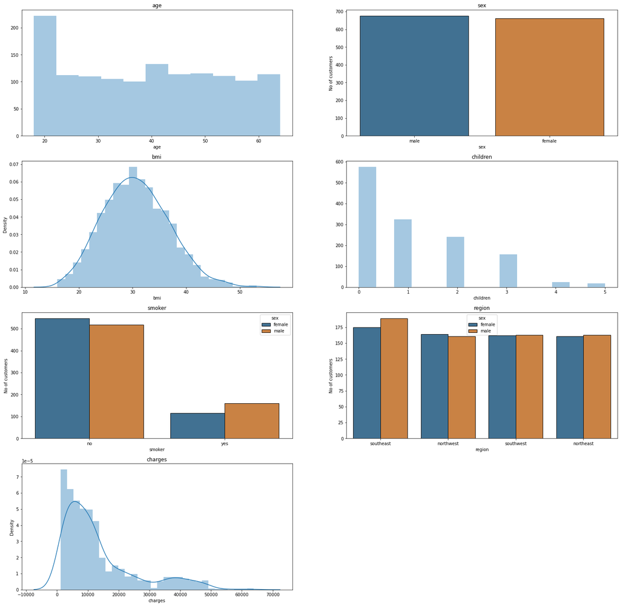

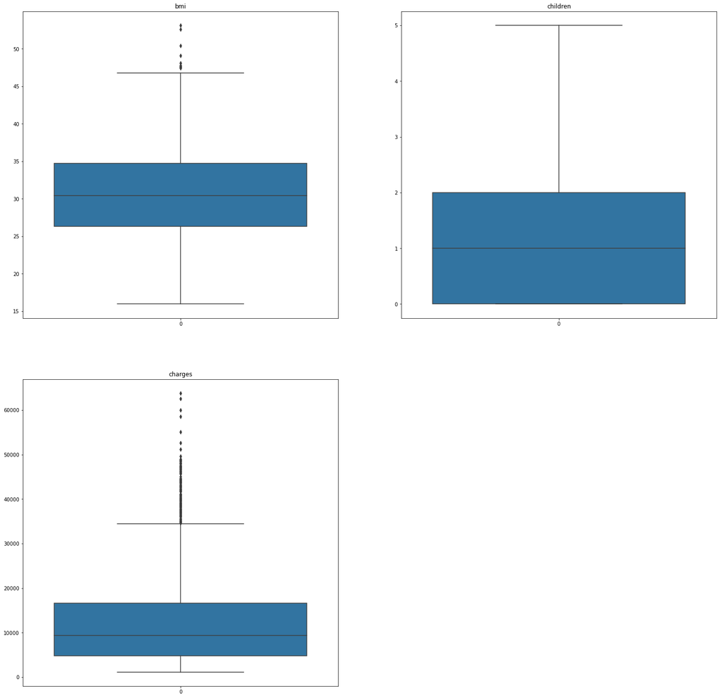

|  | age | sex | bmi | children | smoker | region | charges |
| --- | --- | --- | --- | --- | --- | --- | --- |
| 0 | 19 | 0 | 27.900 | 0 | 1 | 3 | 16884.92400 |
| 1 | 18 | 1 | 33.770 | 1 | 0 | 2 | 1725.55230 |
| 2 | 28 | 1 | 33.000 | 3 | 0 | 2 | 4449.46200 |
| 3 | 33 | 1 | 22.705 | 0 | 0 | 1 | 21984.47061 |
| 4 | 32 | 1 | 28.880 | 0 | 0 | 1 | 3866.85520 |

**Analysis:** The heatmap for Pearson correlation table below proves just pnde explicative variable is has a strong correlation level to the explicative variable, according to Evans classification, Evans (1996, also http://leg.ufpr.br/~silvia/CE003/node74.html, on Brazilian portuguese)

```
<function matplotlib.pyplot.close(fig=None)>
```

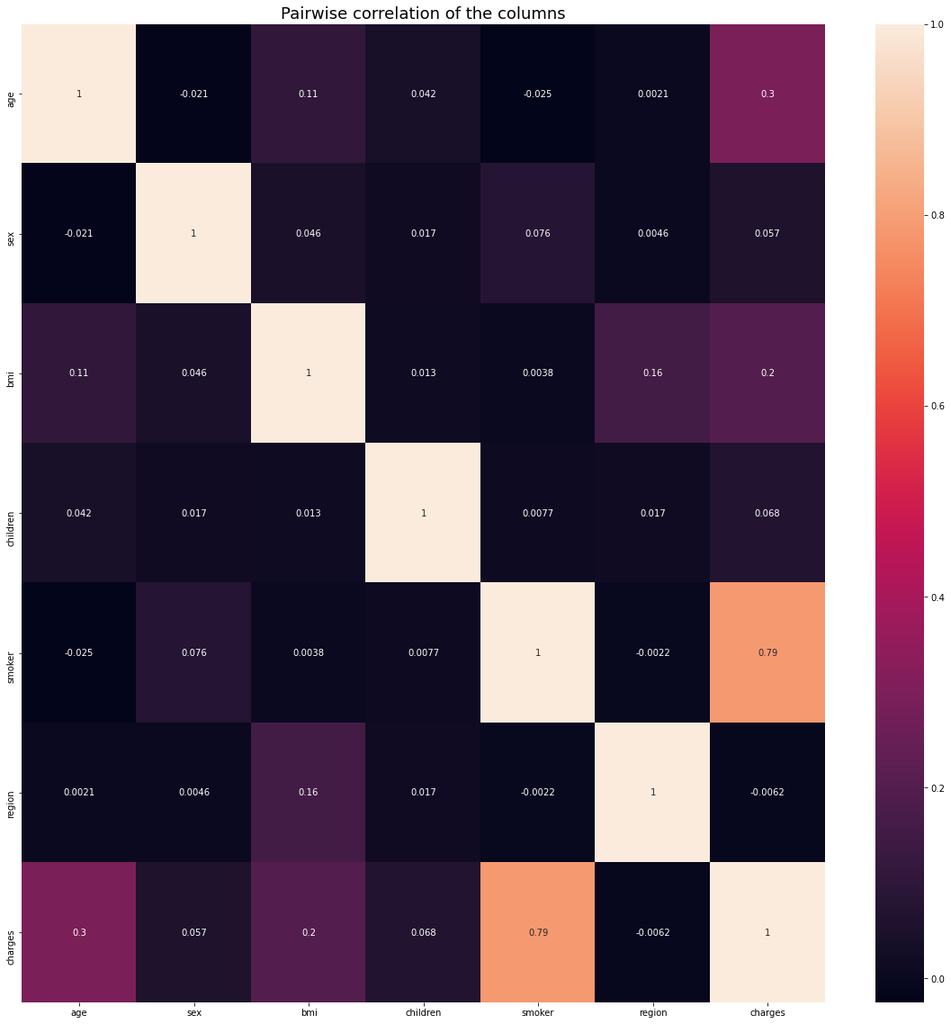

**Analysis:** Pairwise relationships graphics below proves that smoker class is a good explicative variable. Probably, undersampling and oversampling techniques can solve give more powers to this variable because of the unbalanced data.

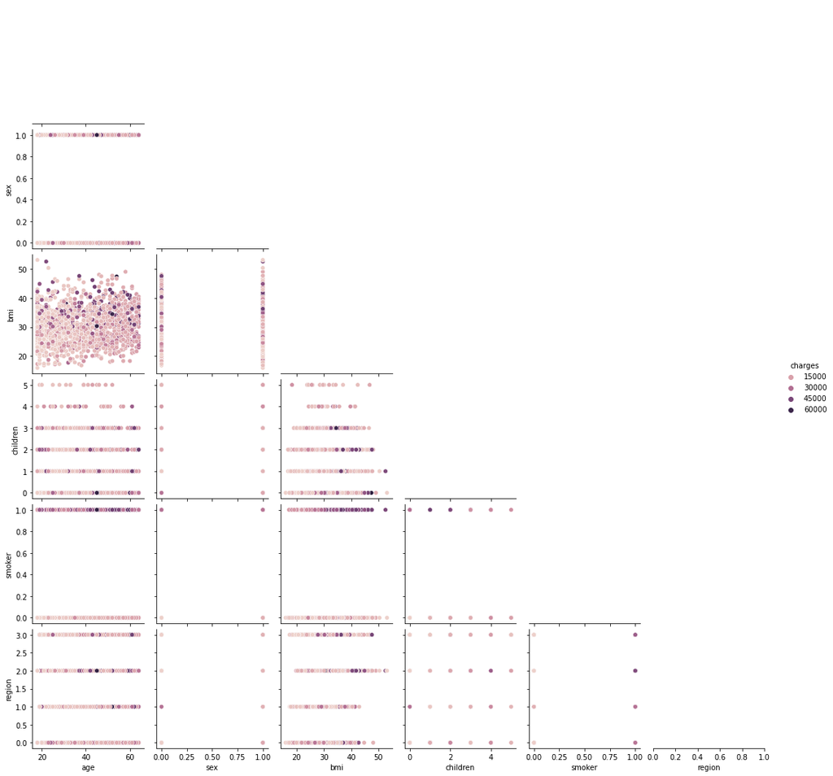

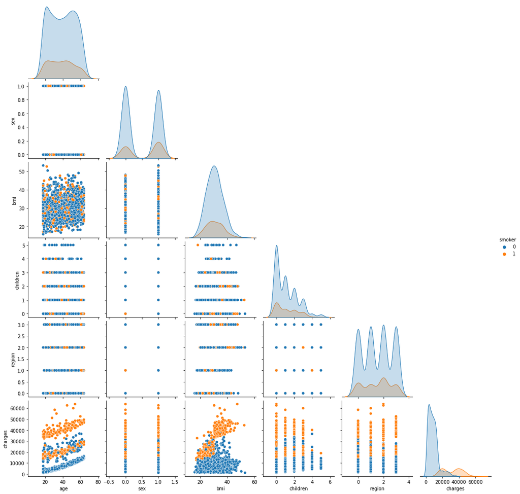

# 3. Model training and testing

## 3.1. No treatment applied on models - With skewed data and no attribute selection

**Explicative variables**

|  | age | sex | bmi | children | smoker | region |
| --- | --- | --- | --- | --- | --- | --- |
| 0 | 19 | 0 | 27.900 | 0 | 1 | 3 |
| 1 | 18 | 1 | 33.770 | 1 | 0 | 2 |
| 2 | 28 | 1 | 33.000 | 3 | 0 | 2 |
| 3 | 33 | 1 | 22.705 | 0 | 0 | 1 |
| 4 | 32 | 1 | 28.880 | 0 | 0 | 1 |

**Response variable**

|  | charges |
| --- | --- |
| 0 | 16884.92400 |
| 1 | 1725.55230 |
| 2 | 4449.46200 |
| 3 | 21984.47061 |
| 4 | 3866.85520 |

```
MAE mean:
	LinearRegression         : 4210.02010
	Lasso                    : 4209.89113
	RandomForestRegressor    : 2659.48325
	GradientBoostingRegressor: 2491.33268
	Ridge                    : 4211.25243
	KNeighborsRegressor      : 3170.78680
	DecisionTreeRegressor    : 2995.56819
	PLSRegression            : 4200.12133
	ElasticNet               : 5122.08177
	XGBRegressor             : 2480.14237
	XGBRFRegressor           : 2496.30104
MSE mean:
	LinearRegression         : 36783193.77841
	Lasso                    : 36782540.76346
	RandomForestRegressor    : 23152335.50410
	GradientBoostingRegressor: 20445436.72334
	Ridge                    : 36780598.66764
	KNeighborsRegressor      : 27753669.32024
	DecisionTreeRegressor    : 41051940.45231
	PLSRegression            : 36778926.65794
	ElasticNet               : 48536026.54399
	XGBRegressor             : 20243518.91227
	XGBRFRegressor           : 20216270.91612
R2 score mean:
	LinearRegression         : 0.74769
	Lasso                    : 0.74769
	RandomForestRegressor    : 0.84131
	GradientBoostingRegressor: 0.85980
	Ridge                    : 0.74771
	KNeighborsRegressor      : 0.80975
	DecisionTreeRegressor    : 0.71779
	PLSRegression            : 0.74772
	ElasticNet               : 0.66815
	XGBRegressor             : 0.86123
	XGBRFRegressor           : 0.86144
Confidence interval - R2 Score - LinearRegression              : (0.7394559155223538, 0.7559198324674242)
Confidence interval - R2 Score - Lasso                         : (0.7394622886770391, 0.7559233369702948)
Confidence interval - R2 Score - RandomForestRegressor         : (0.834659651134665, 0.8479688251116962)
Confidence interval - R2 Score - GradientBoostingRegressor     : (0.8528105440422704, 0.8667824574578684)
Confidence interval - R2 Score - Ridge                         : (0.7394933074094522, 0.7559251336416523)
Confidence interval - R2 Score - KNeighborsRegressor           : (0.8016101792612157, 0.8178878685856495)
Confidence interval - R2 Score - DecisionTreeRegressor         : (0.7063960994097278, 0.7291896931200803)
Confidence interval - R2 Score - PLSRegression                 : (0.7395062880303237, 0.75593383665167)
Confidence interval - R2 Score - ElasticNet                    : (0.6623804213949028, 0.6739148744051916)
Confidence interval - R2 Score - XGBRegressor                  : (0.8544423942081952, 0.8680080907087057)
Confidence interval - R2 Score - XGBRFRegressor                : (0.854539182736403, 0.8683498331106102)
```

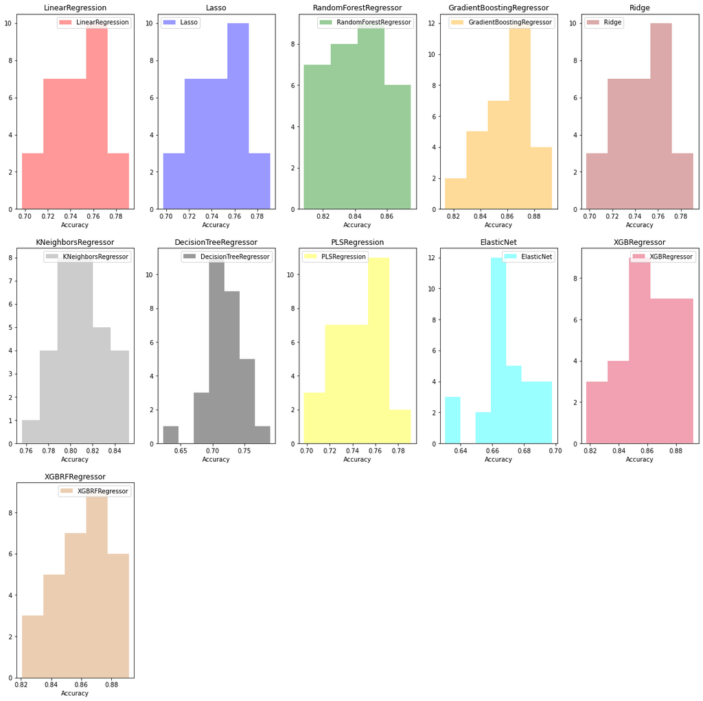

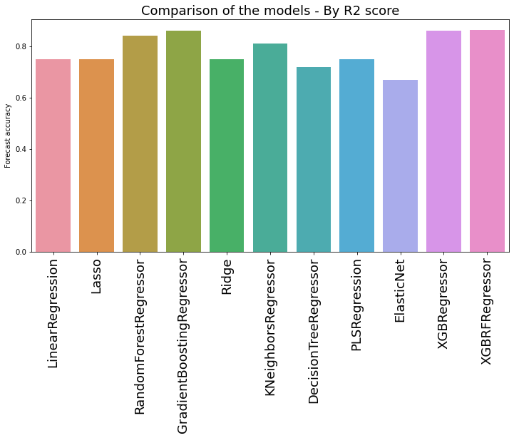

## 3.2. Oversampling and Undersampling Technique - With skewed data, no attribute selection, normalized data with Standard Scaler, dataset size for test 30%

**Analysis:** on exploratory data analysis, it was seen that the main explicative variable ("smoker", 79% according to the "Pairwise correlation of the columns" heatmap table) is unbalanced between its two classes: one class has 3.8832 more times elements than the other one. So, Oversampling and Undersampling technique were choosen to solve this problem and a satisfactory result was achieved. The Oversampling (RandomOverSampler) and Undersampling (RepeatedEditedNearestNeighbours) techniques choosen in this project are the same used in the "Credit Card" classfication project which is in this same Github repository, and on that ocasion they showed a satisfactory performance improvement for the algorithms.

```
Smoker variable's classes distribution before applying Oversampling and Undersampling techniques: (array([0, 1]), array([1064,  274], dtype=int64))
Smoker variable's classes distribution after applying Oversampling and Undersampling techniques:(array([0, 1]), array([958, 958], dtype=int64))
MAE mean:
	LinearRegression         : 5151.11106
	Lasso                    : 5151.09752
	RandomForestRegressor    : 486.80693
	GradientBoostingRegressor: 1064.66498
	Ridge                    : 5151.71165
	KNeighborsRegressor      : 1568.48050
	DecisionTreeRegressor    : 375.24702
	PLSRegression            : 5146.78958
	ElasticNet               : 6536.28149
	XGBRegressor             : 1220.04205
	XGBRFRegressor           : 1144.76666
MSE mean:
	LinearRegression         : 39040850.13499
	Lasso                    : 39040321.02460
	RandomForestRegressor    : 1852265.34925
	GradientBoostingRegressor: 5081325.36721
	Ridge                    : 39042370.94427
	KNeighborsRegressor      : 8771605.41643
	DecisionTreeRegressor    : 2257746.55165
	PLSRegression            : 39084465.66658
	ElasticNet               : 61735895.18693
	XGBRegressor             : 6313375.78411
	XGBRFRegressor           : 4488338.90907
R2 score mean:
	LinearRegression         : 0.84170
	Lasso                    : 0.84170
	RandomForestRegressor    : 0.99249
	GradientBoostingRegressor: 0.97945
	Ridge                    : 0.84169
	KNeighborsRegressor      : 0.96446
	DecisionTreeRegressor    : 0.99083
	PLSRegression            : 0.84152
	ElasticNet               : 0.74989
	XGBRegressor             : 0.97448
	XGBRFRegressor           : 0.98185
Confidence interval - R2 Score - LinearRegression              : (0.8383781350474907, 0.8450181016900963)
Confidence interval - R2 Score - Lasso                         : (0.83838083465144, 0.8450198421750527)
Confidence interval - R2 Score - RandomForestRegressor         : (0.9913893456544426, 0.993587151990062)
Confidence interval - R2 Score - GradientBoostingRegressor     : (0.9779258053085026, 0.9809734565392288)
Confidence interval - R2 Score - Ridge                         : (0.8383714910791248, 0.8450135287946442)
Confidence interval - R2 Score - KNeighborsRegressor           : (0.9626035974181762, 0.9663233400350674)
Confidence interval - R2 Score - DecisionTreeRegressor         : (0.989300041237582, 0.9923692955816975)
Confidence interval - R2 Score - PLSRegression                 : (0.8382474665846982, 0.8447983573755504)
Confidence interval - R2 Score - ElasticNet                    : (0.7459471751389932, 0.7538301417392108)
Confidence interval - R2 Score - XGBRegressor                  : (0.9727140285571158, 0.9762456552813458)
Confidence interval - R2 Score - XGBRFRegressor                : (0.9808029311959624, 0.9828951874932675)
```

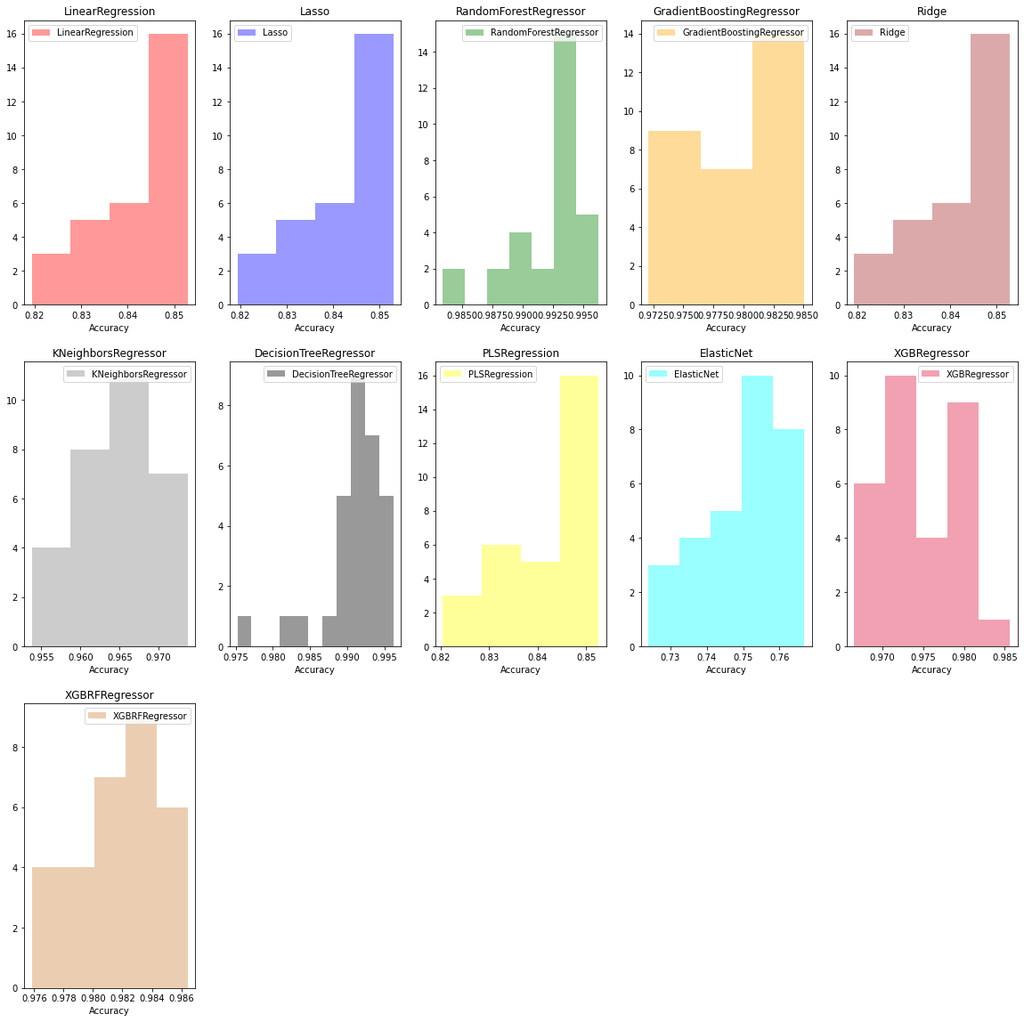

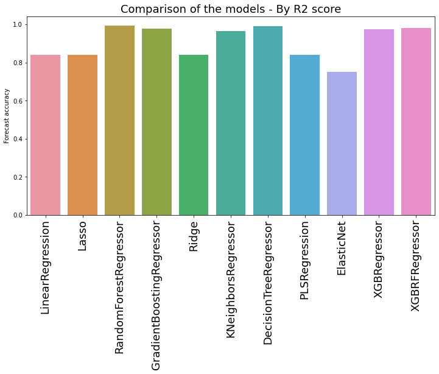

```
Smoker variable's classes distribution before applying Oversampling and Undersampling techniques: (array([0, 1]), array([1064,  274], dtype=int64))
Smoker variable's classes distribution after applying Oversampling and Undersampling techniques:(array([0, 1]), array([958, 958], dtype=int64))
```

# 4. Conclusion